# Guion12.qmd

# Práctica 12 Análisis de expresión diferencial

## Datos

Utilizaremos las medidas de expresión génica del archivo salmon.merged.gene_counts.tsv. Los datos proceden de 12 genotecas de RNA-seq de lecturas emparejadas, de muestras de Drosophila melanogaster de dos orígenes geográficos (Panamá y Maine) y dos tratamientos de temperatura (low y high). Hay 3 réplicas biológicas para cada combinación de región y temperatura.

Además, el archivo dme_elev_samples.tsv, es una tabla que indica a qué región y tratamiento pertenece cada muestra.

## Exploración de los datos

```r
muestras <- read.table('../../data/dme_elev_samples.tsv', header = TRUE)
genex <- read.table('../../data/salmon.merged.gene_counts.tsv',
                    header = TRUE)
```

### Ejercicio 1

1. Usa la función paste() para añadir una columna a muestras que contenga la población y la temperatura unidas por _.

```r
muestras$grupo <- paste(muestras$population, muestras$temp, sep = "_")

head(muestras)
```

```
      sample population temp      grupo
1 SRR1576457      maine  low  maine_low
2 SRR1576458      maine  low  maine_low
3 SRR1576459      maine  low  maine_low
4 SRR1576460      maine high maine_high
5 SRR1576461      maine high maine_high
6 SRR1576462      maine high maine_high
```

2. ¿Cuál es el número total de lecturas por muestra?

```r
 colSums(genex[ , -c(1, 2)])
```

```
SRR1576457 SRR1576458 SRR1576459 SRR1576460 SRR1576461 SRR1576462 SRR1576463
  28252778   21565448   29471559   27692134   26953900   29368135   29706071
SRR1576464 SRR1576465 SRR1576514 SRR1576515 SRR1576516
  26757043   26596118   30950499   25563787   24401671
```

3. ¿Los recuentos tienen distribuciones parecidas entre muestras? Sí, son bastante similares, aunque vemos algunos outlier que varian más

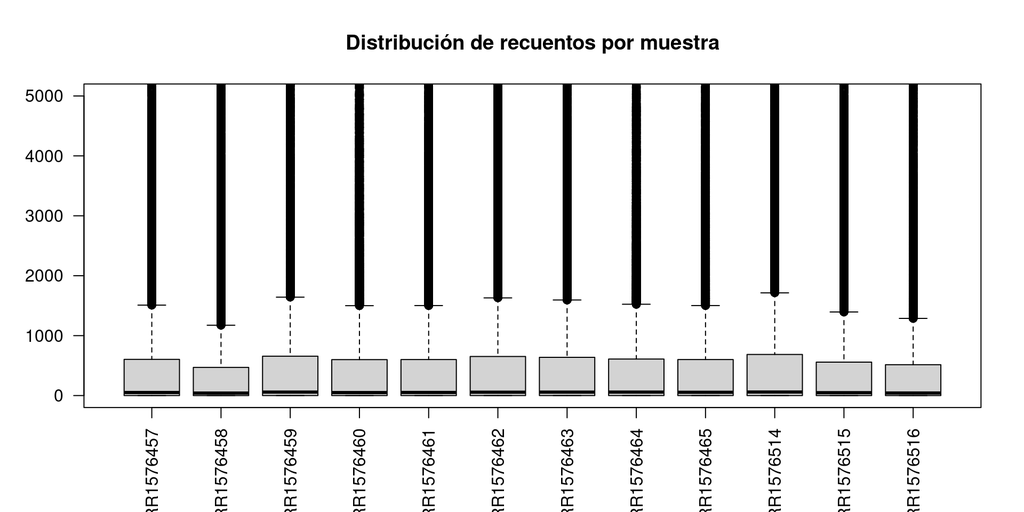

```r
boxplot(genex[ , -c(1, 2)], las = 2, main = "Distribución de recuentos por muestra", ylim = c(0,5000))
```

4. ¿Cuántos genes no se expresan en absoluto en ninguna de las muestras?

```r
sum(rowSums(genex[ , -c(1,2)]) == 0)
```

```
[1] 4722
```

## Crear el objeto de clase DESeqDataSet

Para crear un objeto de clase DESeqDataSet necesitamos que las filas de la tabla muestras estén en el mismo orden que las columnas en genex. La función DESeqDataSetFromMatrix() necesita que los recuentos sean una matriz, no un marco de datos. Y en muestras debe haber factores.

```r
suppressMessages(library('DESeq2'))
all(names(genex)[3:14] == muestras$sample)
```

```
[1] TRUE
```

Esto es una comprobación de que los nombres de las columnas de la 3-14 de la matriz genex, tienen que tener los nombres idénticos a la columna samples.

```r
# Pasamos la columna "sample" a nombres de fila:
row.names(muestras) <- muestras$sample
# Eliminamos la columna "sample":
muestras$sample <- NULL
# Y convertimos "population" y "temp" en factores:
muestras$population <- factor(muestras$population,
                              levels = c('maine', 'panama'))
muestras$temp       <- factor(muestras$temp,
                              levels = c('low', 'high'))
muestras
```

```
           population temp       grupo
SRR1576457      maine  low   maine_low
SRR1576458      maine  low   maine_low
SRR1576459      maine  low   maine_low
SRR1576460      maine high  maine_high
SRR1576461      maine high  maine_high
SRR1576462      maine high  maine_high
SRR1576463     panama  low  panama_low
SRR1576464     panama  low  panama_low
SRR1576465     panama  low  panama_low
SRR1576514     panama high panama_high
SRR1576515     panama high panama_high
SRR1576516     panama high panama_high
```

Un factor es una variable categórica, los niveles, que se pueden ordenar. Se puede calcular los controles con el primer nivel que será el de referencia. Si no especifico los niveles se ponen de forma alfabética.

Los datos de recuento deben ser números enteros y en forma de matriz. Esto es porque los datos vienen de un programa que permite sacar medias, de ahí que no sean números enteros.

```r
row.names(genex) <- genex$gene_name
genex$gene_name <- NULL
genex$gene_id   <- NULL
genex <- round(as.matrix(genex))
```

Lo transformamos en una matríz porque le quitamos el identificador del gen y el nombre. Es decir, las columnas que no son datos.

```r
dds1 <- DESeqDataSetFromMatrix(
   countData = genex,
   colData = muestras,
   design = ~ population + temp
)
dds1
```

```
class: DESeqDataSet
dim: 24254 12
metadata(1): version
assays(1): counts
rownames(24254): 7SLRNA:CR32864 a ... RR51477 Bari1{}RR51478
rowData names(0):
colnames(12): SRR1576457 SRR1576458 ... SRR1576515 SRR1576516
colData names(3): population temp grupo
```

## Pre-filtrado

Una fracción importante de genes no se están expresando en ningúna muestra.

```r
keep <- rowSums(counts(dds1)) > 0
dds1 <- dds1[keep, ]
```

keep es un vector de verdaderos y falsos. Que en una matriz que una fila sea 0 es que no hay expresión, ninguna expesa ese gen. Así reducimos el tamaño.

## Expresión diferencial

Observa que la función DESeq() produce un objeto también de clase DESeqDataSet, pero con resultados añadidos:

```r
dds1 <- DESeq(dds1)
```

```r
res <- results(dds1)
res
```

```
log2 fold change (MLE): temp high vs low
Wald test p-value: temp high vs low
DataFrame with 19508 rows and 6 columns
                baseMean log2FoldChange     lfcSE       stat      pvalue
               <numeric>      <numeric> <numeric>  <numeric>   <numeric>
7SLRNA:CR32864   346.333      0.5918974 1.3301901   0.444972 0.656339979
a                555.596     -0.2730041 0.0718487  -3.799708 0.000144866
abd-A            531.996     -0.0286785 0.0789218  -0.363379 0.716321800
Abd-B            634.760     -0.1083918 0.0771241  -1.405420 0.159896347
Abl             1654.842     -0.1328055 0.0746580  -1.778851 0.075264235
...                  ...            ...       ...        ...         ...
RR51007          4.90906      3.8596869  2.972471  1.2984773 1.94123e-01
RR51048         16.60710     -0.8973071  0.341603 -2.6267530 8.62039e-03
RR51093         36.93279      0.0660523  1.685323  0.0391927 9.68737e-01
RR51475        159.62678     -2.6058194  1.875172 -1.3896429 1.64637e-01
RR51477         70.83394      1.6927986  0.192437  8.7966372 1.40977e-18
                      padj
                 <numeric>
7SLRNA:CR32864  0.81170166
a               0.00154574
abd-A           0.85146309
Abd-B           0.33849233
Abl             0.20046251
...                    ...
RR51007        3.82417e-01
RR51048        4.01746e-02
RR51093        9.84464e-01
RR51475        3.44815e-01
RR51477        2.06431e-16
```

los valores de log2FoldChange representan el logaritmo en base 2 de la relación entre niveles de expresión en muestras high respecto de muestras low.

### Ejercicio 3

Mira la ayuda de results() y genera también la tabla de resultados para el contraste entre las dos regiones de procedencia de las moscas.

```r
región <- results(dds1, contrast = c( "population", "panama", "maine"))
región.df <- as.data.frame(región)
```

Usa summary() sobre los resultados para ver el número de genes diferencialmente expresados entre cada par de condiciones.

Para tempeartura:

```r
temperatura <- results(dds1, contrast = c( "temp", "low", "high"))
temperatura.df <- as.data.frame(temperatura)
```

```r
summary(res)
```

```
out of 19508 with nonzero total read count
adjusted p-value < 0.1
LFC > 0 (up)       : 2418, 12%
LFC < 0 (down)     : 2336, 12%
outliers [1]       : 90, 0.46%
low counts [2]     : 3018, 15%
(mean count < 2)
[1] see 'cooksCutoff' argument of ?results
[2] see 'independentFiltering' argument of ?results
```

¿Cuál es la tasa de falsos positivos (FDR)? 0.1

## Gráficas

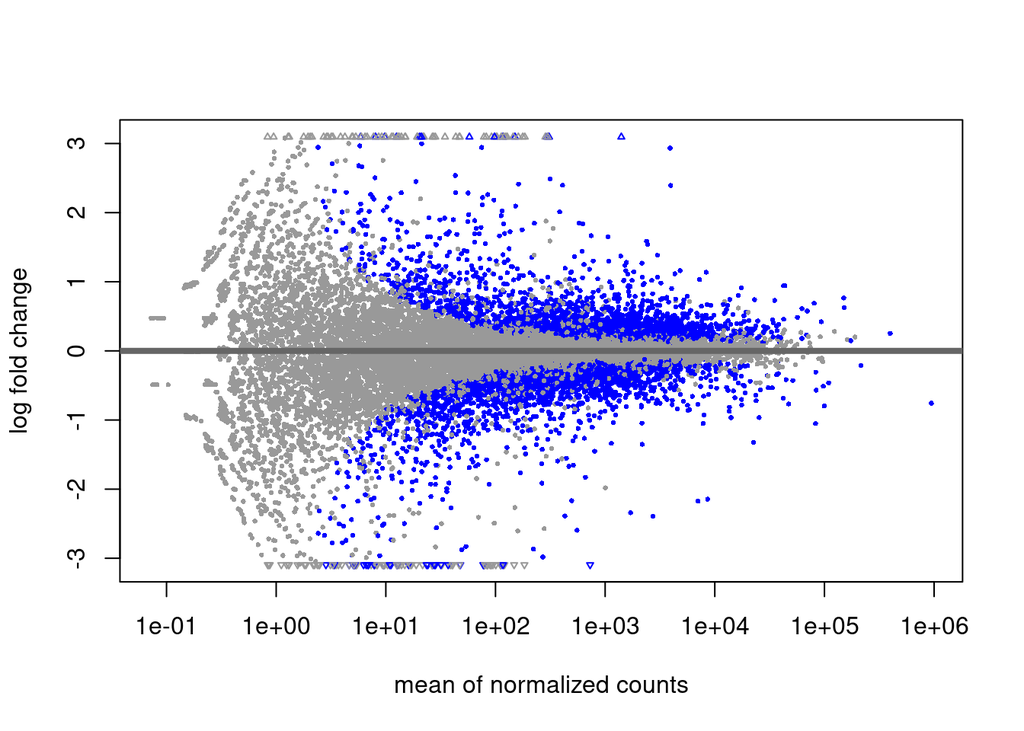

```r
plotMA(res)
```

Los genes con niveles de expresión más bajos producen resultados más ruidosos (la varianza es mayor). La función lfcShrink() contrae (shrink) las estimaciones de los efectos (log fold change) para reducir el ruido y hacer el resultado más realista:

```r
resShrink <- lfcShrink(dds1, coef = 'temp_high_vs_low',
                       type = 'normal')
```

```
using 'normal' for LFC shrinkage, the Normal prior from Love et al (2014).

Note that type='apeglm' and type='ashr' have shown to have less bias than type='normal'.
See ?lfcShrink for more details on shrinkage type, and the DESeq2 vignette.
Reference: https://doi.org/10.1093/bioinformatics/bty895
```

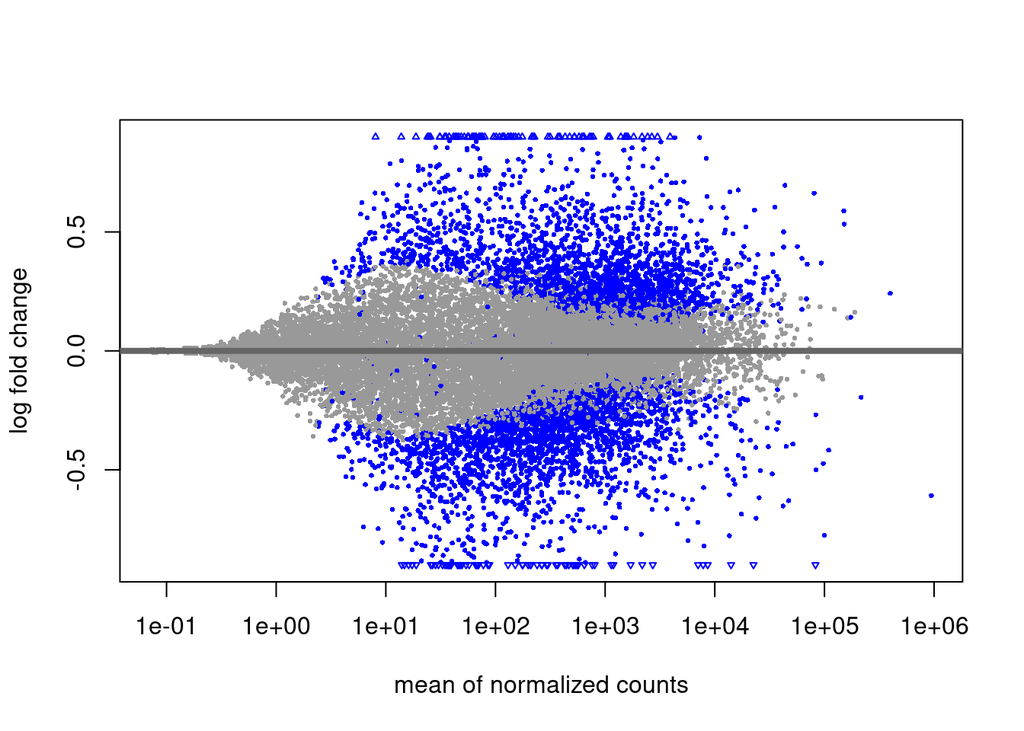

```r
plotMA(resShrink)
```